# 1. Introduction

[figure not shown]

## 1.1 About the Dataset

The dataset is retrived from [Ulrik Thyge Pedersen](https://www.kaggle.com/datasets/ulrikthygepedersen/speed-dating) on Kaggle. This data was gathered from participants in experimental speed dating events from 2002-2004. During the events, the attendees would have a four-minute "first date" with every other participant of the opposite sex. At the end of their four minutes, participants were asked if they would like to see their date again. They were also asked to rate their date on six attributes: Attractiveness, Sincerity, Intelligence, Fun, Ambition, and Shared Interests. The dataset also includes questionnaire data gathered from participants at different points in the process. These fields include: demographics, dating habits, self-perception across key attributes, beliefs on what others find valuable in a mate, and lifestyle information.

| Variable | Description |
| --- | --- |
| gender | Gender of self |
| age | Age of self |
| age_o | Age of partner |
| d_age | Difference in age |
| d_age | Difference in age |
| race | Race of self |
| race_o | Race of partner |
| samerace | Whether the two persons have the same race or not. |
| importance_same_race | How important is it that partner is of same race? |
| importance_same_religion | How important is it that partner has same religion? |
| field | Field of study |
| pref_o_attractive | How important does partner rate attractiveness |
| pref_o_sinsere | How important does partner rate sincerity |
| pref_o_intelligence | How important does partner rate intelligence |
| pref_o_funny | How important does partner rate being funny |
| pref_o_ambitious | How important does partner rate ambition |
| pref_o_shared_interests | How important does partner rate having shared interests |
| attractive_o | Rating by partner (about me) at night of event on attractiveness |
| sincere_o | Rating by partner (about me) at night of event on sincerity |
| intelligence_o | Rating by partner (about me) at night of event on intelligence |
| funny_o | Rating by partner (about me) at night of event on being funny |
| ambitous_o | Rating by partner (about me) at night of event on being ambitious |
| shared_interests_o | Rating by partner (about me) at night of event on shared interest |
| attractive_important | What do you look for in a partner - attractiveness |
| sincere_important | What do you look for in a partner - sincerity |
| intellicence_important | What do you look for in a partner - intelligence |
| funny_important | What do you look for in a partner - being funny |
| ambtition_important | What do you look for in a partner - ambition |
| shared_interests_important | What do you look for in a partner - shared interests |
| attractive | Rate yourself - attractiveness |
| sincere | Rate yourself - sincerity |
| intelligence | Rate yourself - intelligence |
| funny | Rate yourself - being funny |
| ambition | Rate yourself - ambition |
| attractive_partner | Rate your partner - attractiveness |
| sincere_partner | Rate your partner - sincerity |
| intelligence_partner | Rate your partner - intelligence |
| funny_partner | Rate your partner - being funny |
| ambition_partner | Rate your partner - ambition |
| shared_interests_partner | Rate your partner - shared interests |
| sports | Your own interests [1-10] |
| interests_correlate | Correlation between participant’s and partner’s ratings of interests. |
| expected_happy_with_sd_people | How happy do you expect to be with the people you meet during the speed-dating event? |
| expected_num_interested_in_me | Out of the 20 people you will meet, how many do you expect will be interested in dating you? |
| expected_num_matches | How many matches do you expect to get? |
| like | Did you like your partner? |
| guess_prob_liked | How likely do you think it is that your partner likes you? |
| met | Have you met your partner before? |
| decision | Decision at night of event. |
| decision_o | Decision of partner at night of event. |
| match | Match (yes/no) |

## 1.2 Purpose

- To clean the dataset and make it ready for a classification problem to determine whether the speed date is a match or not
- Conduct dimension reduction using various techniques to find the most important features to predict whether the date is a match or not

## 1.3 Further insight

I have written an article explaining the steps followed in dimension reduction of the dataset and it can be found [HERE](https://thesilentguru.com/dimension-reduction-in-python/)

# 2. Import libraries and read files

```python
import numpy as np # linear algebra
import pandas as pd # data processing, CSV file I/O (e.g. pd.read_csv)
import matplotlib.pyplot as plt
import seaborn as sns

from sklearn.decomposition import PCA
from sklearn.pipeline import Pipeline
from sklearn.preprocessing import StandardScaler, OneHotEncoder
from sklearn.model_selection import train_test_split, cross_val_score
from sklearn.impute import SimpleImputer
from sklearn.feature_extraction import DictVectorizer

from sklearn.linear_model import LogisticRegression
from sklearn.svm import SVC
from sklearn.neighbors import KNeighborsClassifier
from sklearn.ensemble import RandomForestClassifier
from sklearn.decomposition import PCA
import xgboost as xgb

import re
```

```python
# Set default options
pd.set_option('display.max_columns', 150)
pd.set_option('display.max_rows', 130)
```

```python
# Read dataset
dating = pd.read_csv('speeddating.csv')
```

# 3.Preview file

```python
dating.head()
```

|  | has_null | wave | gender | age | age_o | d_age | d_d_age | race | race_o | samerace | importance_same_race | importance_same_religion | d_importance_same_race | d_importance_same_religion | field | pref_o_attractive | pref_o_sincere | pref_o_intelligence | pref_o_funny | pref_o_ambitious | pref_o_shared_interests | d_pref_o_attractive | d_pref_o_sincere | d_pref_o_intelligence | d_pref_o_funny | d_pref_o_ambitious | d_pref_o_shared_interests | attractive_o | sinsere_o | … |
| --- | --- | --- | --- | --- | --- | --- | --- | --- | --- | --- | --- | --- | --- | --- | --- | --- | --- | --- | --- | --- | --- | --- | --- | --- | --- | --- | --- | --- | --- | --- |
| 0 | b'' | 1.0 | b'female' | 21.0 | 27.0 | 6.0 | b'[4-6]' | b'Asian/Pacific Islander/Asian-American' | b'European/Caucasian-American' | b'0' | 2.0 | 4.0 | b'[2-5]' | b'[2-5]' | b'Law' | 35.0 | 20.0 | 20.0 | 20.0 | 0.0 | 5.0 | b'[21-100]' | b'[16-20]' | b'[16-20]' | b'[16-20]' | b'[0-15]' | b'[0-15]' | 6.0 | 8.0 | … |
| 1 | b'' | 1.0 | b'female' | 21.0 | 22.0 | 1.0 | b'[0-1]' | b'Asian/Pacific Islander/Asian-American' | b'European/Caucasian-American' | b'0' | 2.0 | 4.0 | b'[2-5]' | b'[2-5]' | b'Law' | 60.0 | 0.0 | 0.0 | 40.0 | 0.0 | 0.0 | b'[21-100]' | b'[0-15]' | b'[0-15]' | b'[21-100]' | b'[0-15]' | b'[0-15]' | 7.0 | 8.0 | … |
| 2 | b'' | 1.0 | b'female' | 21.0 | 22.0 | 1.0 | b'[0-1]' | b'Asian/Pacific Islander/Asian-American' | b'Asian/Pacific Islander/Asian-American' | b'1' | 2.0 | 4.0 | b'[2-5]' | b'[2-5]' | b'Law' | 19.0 | 18.0 | 19.0 | 18.0 | 14.0 | 12.0 | b'[16-20]' | b'[16-20]' | b'[16-20]' | b'[16-20]' | b'[0-15]' | b'[0-15]' | 10.0 | 10.0 | … |
| 3 | b'' | 1.0 | b'female' | 21.0 | 23.0 | 2.0 | b'[2-3]' | b'Asian/Pacific Islander/Asian-American' | b'European/Caucasian-American' | b'0' | 2.0 | 4.0 | b'[2-5]' | b'[2-5]' | b'Law' | 30.0 | 5.0 | 15.0 | 40.0 | 5.0 | 5.0 | b'[21-100]' | b'[0-15]' | b'[0-15]' | b'[21-100]' | b'[0-15]' | b'[0-15]' | 7.0 | 8.0 | … |
| 4 | b'' | 1.0 | b'female' | 21.0 | 24.0 | 3.0 | b'[2-3]' | b'Asian/Pacific Islander/Asian-American' | b'Latino/Hispanic American' | b'0' | 2.0 | 4.0 | b'[2-5]' | b'[2-5]' | b'Law' | 30.0 | 10.0 | 20.0 | 10.0 | 10.0 | 20.0 | b'[21-100]' | b'[0-15]' | b'[16-20]' | b'[0-15]' | b'[0-15]' | b'[16-20]' | 8.0 | 7.0 | … |

```python
dating.info()
```

```
<class 'pandas.core.frame.DataFrame'>
RangeIndex: 8378 entries, 0 to 8377
Columns: 123 entries, has_null to match
dtypes: float64(59), object(64)
memory usage: 7.9+ MB
```

```python
dating.shape
```

```
(8378, 123)
```

# 4. Data preprocessing

## 4.1 Checking column data types

```python
dating.dtypes
```

```
has_null                            object
wave                               float64
gender                              object
age                                float64
age_o                              float64
d_age                              float64
d_d_age                             object
race                                object
race_o                              object
samerace                            object
importance_same_race               float64
importance_same_religion           float64
d_importance_same_race              object
d_importance_same_religion          object
field                               object
pref_o_attractive                  float64
pref_o_sincere                     float64
pref_o_intelligence                float64
pref_o_funny                       float64
pref_o_ambitious                   float64
pref_o_shared_interests            float64
d_pref_o_attractive                 object
d_pref_o_sincere                    object
d_pref_o_intelligence               object
d_pref_o_funny                      object
d_pref_o_ambitious                  object
d_pref_o_shared_interests           object
attractive_o                       float64
sinsere_o                          float64
intelligence_o                     float64
funny_o                            float64
ambitous_o                         float64
shared_interests_o                 float64
d_attractive_o                      object
d_sinsere_o                         object
d_intelligence_o                    object
d_funny_o                           object
d_ambitous_o                        object
d_shared_interests_o                object
attractive_important               float64
```

[output cut: 69 more lines]

```
expected_happy_with_sd_people      float64
expected_num_interested_in_me      float64
expected_num_matches               float64
d_expected_happy_with_sd_people     object
d_expected_num_interested_in_me     object
d_expected_num_matches              object
like                               float64
guess_prob_liked                   float64
d_like                              object
d_guess_prob_liked                  object
met                                float64
decision                            object
decision_o                          object
match                               object
dtype: object
```

## 4.2 Removing unwanted characters

All string columns have an unwanted character 'b' and are enclosed by single quotes. We will remove these characters from the columns.

```python
dating.head(3)
```

|  | has_null | wave | gender | age | age_o | d_age | d_d_age | race | race_o | samerace | importance_same_race | importance_same_religion | d_importance_same_race | d_importance_same_religion | field | pref_o_attractive | pref_o_sincere | pref_o_intelligence | pref_o_funny | pref_o_ambitious | pref_o_shared_interests | d_pref_o_attractive | d_pref_o_sincere | d_pref_o_intelligence | d_pref_o_funny | d_pref_o_ambitious | d_pref_o_shared_interests | attractive_o | sinsere_o | … |
| --- | --- | --- | --- | --- | --- | --- | --- | --- | --- | --- | --- | --- | --- | --- | --- | --- | --- | --- | --- | --- | --- | --- | --- | --- | --- | --- | --- | --- | --- | --- |
| 0 | b'' | 1.0 | b'female' | 21.0 | 27.0 | 6.0 | b'[4-6]' | b'Asian/Pacific Islander/Asian-American' | b'European/Caucasian-American' | b'0' | 2.0 | 4.0 | b'[2-5]' | b'[2-5]' | b'Law' | 35.0 | 20.0 | 20.0 | 20.0 | 0.0 | 5.0 | b'[21-100]' | b'[16-20]' | b'[16-20]' | b'[16-20]' | b'[0-15]' | b'[0-15]' | 6.0 | 8.0 | … |
| 1 | b'' | 1.0 | b'female' | 21.0 | 22.0 | 1.0 | b'[0-1]' | b'Asian/Pacific Islander/Asian-American' | b'European/Caucasian-American' | b'0' | 2.0 | 4.0 | b'[2-5]' | b'[2-5]' | b'Law' | 60.0 | 0.0 | 0.0 | 40.0 | 0.0 | 0.0 | b'[21-100]' | b'[0-15]' | b'[0-15]' | b'[21-100]' | b'[0-15]' | b'[0-15]' | 7.0 | 8.0 | … |
| 2 | b'' | 1.0 | b'female' | 21.0 | 22.0 | 1.0 | b'[0-1]' | b'Asian/Pacific Islander/Asian-American' | b'Asian/Pacific Islander/Asian-American' | b'1' | 2.0 | 4.0 | b'[2-5]' | b'[2-5]' | b'Law' | 19.0 | 18.0 | 19.0 | 18.0 | 14.0 | 12.0 | b'[16-20]' | b'[16-20]' | b'[16-20]' | b'[16-20]' | b'[0-15]' | b'[0-15]' | 10.0 | 10.0 | … |

```python
# We create a function that removes all the unwanted characters
def remove_xters(feature):
    return feature.replace("b'",'').replace("'","")

# We select string columns and apply the transformation
string_dataset = dating.select_dtypes(include = ['object'])

for feature in string_dataset.columns:
    dating[feature] = dating[feature].apply(lambda x: remove_xters(x))

dating[string_dataset.columns].head(3)
```

|  | has_null | gender | d_d_age | race | race_o | samerace | d_importance_same_race | d_importance_same_religion | field | d_pref_o_attractive | d_pref_o_sincere | d_pref_o_intelligence | d_pref_o_funny | d_pref_o_ambitious | d_pref_o_shared_interests | d_attractive_o | d_sinsere_o | d_intelligence_o | d_funny_o | d_ambitous_o | d_shared_interests_o | d_attractive_important | d_sincere_important | d_intellicence_important | d_funny_important | d_ambtition_important | d_shared_interests_important | d_attractive | d_sincere | … |
| --- | --- | --- | --- | --- | --- | --- | --- | --- | --- | --- | --- | --- | --- | --- | --- | --- | --- | --- | --- | --- | --- | --- | --- | --- | --- | --- | --- | --- | --- | --- |
| 0 |  | female | [4-6] | Asian/Pacific Islander/Asian-American | European/Caucasian-American | 0 | [2-5] | [2-5] | Law | [21-100] | [16-20] | [16-20] | [16-20] | [0-15] | [0-15] | [6-8] | [6-8] | [6-8] | [6-8] | [6-8] | [6-8] | [0-15] | [16-20] | [16-20] | [0-15] | [0-15] | [0-15] | [6-8] | [6-8] | … |
| 1 |  | female | [0-1] | Asian/Pacific Islander/Asian-American | European/Caucasian-American | 0 | [2-5] | [2-5] | Law | [21-100] | [0-15] | [0-15] | [21-100] | [0-15] | [0-15] | [6-8] | [6-8] | [9-10] | [6-8] | [6-8] | [0-5] | [0-15] | [16-20] | [16-20] | [0-15] | [0-15] | [0-15] | [6-8] | [6-8] | … |
| 2 |  | female | [0-1] | Asian/Pacific Islander/Asian-American | Asian/Pacific Islander/Asian-American | 1 | [2-5] | [2-5] | Law | [16-20] | [16-20] | [16-20] | [16-20] | [0-15] | [0-15] | [9-10] | [9-10] | [9-10] | [9-10] | [9-10] | [9-10] | [0-15] | [16-20] | [16-20] | [0-15] | [0-15] | [0-15] | [6-8] | [6-8] | … |

```python
# Drop the has_null and wave columns
dating.drop(['has_null','wave'], axis = 1, inplace= True)
```

The same race variable is a string data type. We convert it to numeric

```python
dating['samerace'] = dating['samerace'].astype('int')
```

## 4.3 Dropping columns

### 4.3.1 Age

There are four different columns for age and these are: age of individual, age of partner, age difference, and age group (where ages have been binned into categories). However the age difference column is not standardized since the difference is between the higher age and the lower age. We will standardize the difference by subtracting age between each individual and their partner. Since the direction of the difference matters, the column will have both positive and negative values. We will then drop the other age columns

```python
# Create age difference column
dating['age_diff'] = dating['age'] - dating['age_o']

# Drop other age columns
dating.drop(['age','age_o', 'd_age', 'd_d_age'], axis = 1, inplace = True)
```

### 4.3.2 Binned variables

The speed dating dataset has some of the numeric features binned into categories. This is a duplication of information which increases the dimensionality of the dataset without adding any significant value. We will remove all the duplicated features. Conveniently, the names of these binned features have the prefix "d_". We will use this to subset and remove these features. Before the selection, the dataset has 118 features, and after the selection, we remain with 64 features.

```python
dating.shape
```

```
(8378, 118)
```

```python
to_drop = [column_name for column_name in dating.columns if column_name.startswith('d_')]
dating.drop(to_drop, axis = 1, inplace = True)
dating.shape
```

```
(8378, 64)
```

### 4.3.3 Field

In the individual field indicating their careers, there's an overlapping of values. For instance, Business, which is the most popular field still comprises of MBA (2nd most popular), Finance, business [MBA] etc. Physics, Chemistry, Biology all fall under science. Due to this variation and overlapping, we will drop the column

```python
display(dating.field.value_counts().head(30))
dating.drop('field',axis = 1, inplace = True)
```

```
Business                  521
MBA                       468
Law                       462
Social Work               378
International Affairs     252
Electrical Engineering    164
Psychology                139
law                       123
Finance                   113
business                  110
Mathematics                95
Film                       92
Sociology                  88
Biology                    85
Engineering                81
Business [MBA]             77
Clinical Psychology        76
Biochemistry               70
Political Science          69
Economics                  67
?                          63
chemistry                  57
Physics                    56
Operations Research        56
School Psychology          56
Education                  55
medicine                   52
sociology                  52
Mechanical Engineering     51
Urban Planning             50
Name: field, dtype: int64
```

### 4.3.4 Met

The variable met answers the question as to whether the person has previously met the partner. Since the responses are either yes(1) or no (0), we will clean the column and change responses with neither values, and replace them with the most frequent value. Since they are only a few values, they will not skew our data.

```python
print(f'Before \n{dating.met.value_counts()}')

for number in [3.0, 5.0, 6.0, 7.0, 8.0]:
    dating['met'].replace(number,0, inplace =True)

print(f'\nAfter \n{dating.met.value_counts()}')
```

```
Before
0.0    7644
1.0     351
7.0       3
5.0       2
3.0       1
8.0       1
6.0       1
Name: met, dtype: int64

After
0.0    7652
1.0     351
Name: met, dtype: int64
```

### 4.3.5 Variables similar to the y variable

The two variables 'decision' and 'decision_o' have similar responses almost similar to the variable being predicted. We will therefore remove these two features.

```python
display(dating.groupby('decision')['match'].value_counts())
print()
display(dating.groupby('decision_o')['match'].value_counts())

dating.drop(['decision_o','decision'], axis = 1, inplace = True)
```

```
decision  match
0         0        4860
1         0        2138
          1        1380
Name: match, dtype: int64
```

```
decision_o  match
0           0        4863
1           0        2135
            1        1380
Name: match, dtype: int64
```

## 4.4 Numeric and categorical columns

```python
# Selecting numeric columns
columns_numeric = dating.select_dtypes(include = ['int','float']).columns.tolist()

# Selecting categorical columns
columns_category = dating.select_dtypes(include = ['object']).drop('match', axis=1).columns
```

## 4.5. Missing values

More than 78% of values in the variable "expected_num_interested_in_me" are missing. This variable will therefore be dropped. The rest of the features will be imputed with the median value of each feature.

```python
# Show the missing values
display(dating[columns_numeric].isna().sum()/len(dating)*100)

# Drop the variable with lots of missing values from the dataset
dating.drop('expected_num_interested_in_me', axis = 1, inplace = True)

# Delete it from the numeric column list

columns_numeric.remove('expected_num_interested_in_me')
```

```
samerace                          0.000000
importance_same_race              0.942946
importance_same_religion          0.942946
pref_o_attractive                 1.062306
pref_o_sincere                    1.062306
pref_o_intelligence               1.062306
pref_o_funny                      1.169730
pref_o_ambitious                  1.277154
pref_o_shared_interests           1.539747
attractive_o                      2.530437
sinsere_o                         3.425639
intelligence_o                    3.652423
funny_o                           4.296968
ambitous_o                        8.617809
shared_interests_o               12.843161
attractive_important              0.942946
sincere_important                 0.942946
intellicence_important            0.942946
funny_important                   1.062306
ambtition_important               1.181666
shared_interests_important        1.444259
attractive                        1.253282
sincere                           1.253282
intelligence                      1.253282
funny                             1.253282
ambition                          1.253282
attractive_partner                2.411077
sincere_partner                   3.306278
intelligence_partner              3.533063
funny_partner                     4.177608
ambition_partner                  8.498448
shared_interests_partner         12.735736
sports                            0.942946
tvsports                          0.942946
exercise                          0.942946
dining                            0.942946
museums                           0.942946
art                               0.942946
hiking                            0.942946
gaming                            0.942946
clubbing                          0.942946
reading                           0.942946
tv                                0.942946
theater                           0.942946
movies                            0.942946
concerts                          0.942946
music                             0.942946
shopping                          0.942946
yoga                              0.942946
interests_correlate               1.885892
expected_happy_with_sd_people     1.205538
expected_num_interested_in_me    78.515159
expected_num_matches             14.000955
like                              2.864646
guess_prob_liked                  3.688231
met                               4.476009
age_diff                          2.363333
dtype: float64
```

```python
# Save the clean dataset for future analysis
dating.to_csv('speed_dating_cleaned.csv')
```

# 5. Split dataset into training and test set

```python
X = dating.drop('match', axis = 1)
y = dating['match'].astype('int')
```

```python
X_train, X_test, y_train, y_test = train_test_split(X, y, random_state = 33 )
```

# 6. Imputing, scaling and encoding

## 6.1 Numeric variables

Numeric variables will be imputed by filling missing values with the median value and standardized using the standard scaler.

```python
# Instantiate the numeric imputer and scaler
num_imp = SimpleImputer(strategy = 'median')
scaler = StandardScaler()
```

```python
# Impute the training set
X_train_imp = num_imp.fit_transform(X_train[columns_numeric])

# Scale the training set
X_train_imp_scaled = scaler.fit_transform(X_train_imp)

# Convert the training set to a dataframe
X_train_num_final = pd.DataFrame(X_train_imp_scaled, columns = columns_numeric)
```

```python
# Impute the test set
X_test_imp = num_imp.fit_transform(X_test[columns_numeric])

# Scale the test set
X_test_imp_scaled = scaler.fit_transform(X_test_imp)

# Convert the test set to a dataframe
X_test_num_final = pd.DataFrame(X_test_imp_scaled, columns = columns_numeric)
```

## 6.2 Categorical variables

Categorical variables will be imputed by filling missing values with the value "Unknown". The variables will then be encoded into numeric values using the dictvectorizer.

```python
# Instantiate the categorical imputer and the dictvectorizer
cat_imp = SimpleImputer(missing_values = '?', fill_value = 'Unknown', strategy = 'constant')
vectorizer = DictVectorizer(sparse = False)
```

```python
# Impute the training set
X_train_imp = cat_imp.fit_transform(X_train[columns_category])

# Convert to dataframe
X_train_imp_df = pd.DataFrame(X_train_imp, columns = columns_category)

# Encode the training set
X_train_cat_vect = vectorizer.fit_transform(X_train_imp_df[columns_category].to_dict('records'))

# Convert to dataframe
X_train_cat_final = pd.DataFrame(X_train_cat_vect, columns = vectorizer.get_feature_names_out())
```

```python
# Impute the test set
X_test_imp = cat_imp.fit_transform(X_test[columns_category])

# Convert to dataframe
X_test_imp_df = pd.DataFrame(X_test_imp, columns = columns_category)

# Encode the test set
X_test_cat_vect = vectorizer.fit_transform(X_test_imp_df[columns_category].to_dict('records'))

# Convert to dataframe
X_test_cat_final = pd.DataFrame(X_test_cat_vect, columns = vectorizer.get_feature_names_out())
```

## 6.3 Join numeric and categorical variables

The transformed numeric and categorical variables are joined together to form the training set and test set. The transformations and one hot encoding creates datasets with 70 features.

```python
# Join numeric and categorical variables to create training set
X_train = pd.concat([X_train_num_final,X_train_cat_final], axis = 1)

# Join numeric and categorical variables to create test set
X_test = pd.concat([X_test_num_final,X_test_cat_final], axis = 1)

print('Training set shape is',X_train.shape, 'and test shape shape is',X_test.shape)
```

```
Training set shape is (6283, 70) and test shape shape is (2095, 70)
```

# 7. Model evaluation before dimension reduction

We train and evaluate our models before we begin dimension reduction to find the accuracy when we use all the features. We will use the xgboost classifier for our evaluation since it has the highest accuracy of 0.875. This will therefore be the base value with which we will compare the accuracy of our model after dimension reduction

```python
# We instantiate different models to test their accuracy
logreg = LogisticRegression(max_iter = 10000)
svc = SVC()
knn = KNeighborsClassifier()
rf = RandomForestClassifier()
xg_cl = xgb.XGBClassifier()

classifiers = [('logreg',logreg),('svc',svc),('knn',knn),('random forest',rf),('xgboost',xg_cl)]

# We fit the different models and compute the accuracy
for clf_name, model in classifiers:
    model.fit(X_train, y_train)
    y_pred = model.predict(X_test)
    accuracy = (np.sum(y_pred == y_test))/(len(y_pred))
    print(clf_name, accuracy)
```

```
logreg 0.8606205250596659
svc 0.8725536992840095
knn 0.837708830548926
random forest 0.8730310262529833
xgboost 0.8749403341288783
```

# 8. Dimension reduction

## 8.1 Feature selection with Random forests

Random forest classifiers have a feature importances attribute that shows the contribution of each feature to the model.

```python
rf = RandomForestClassifier()

# Fit the classifier
rf.fit(X_train, y_train)

# Retrieve the feature importances
rf_importance = pd.Series(rf.feature_importances_, index = rf.feature_names_in_)
rf_importance = rf_importance.sort_values(ascending = False)
rf_importance.head()
```

```
like                  0.047911
attractive_o          0.047487
shared_interests_o    0.041242
funny_o               0.039958
funny_partner         0.037625
dtype: float64
```

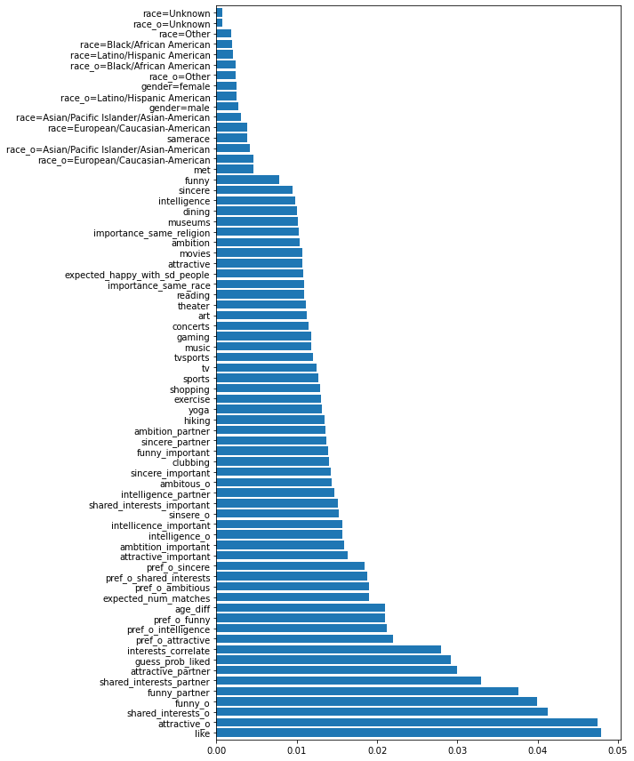

```python
# Visualizing the feature importances
fig = plt.figure(figsize = (10,12))
rf_importance.plot(kind = 'barh', width =0.8)
plt.tight_layout()
plt.show()
```

The feature importance values of random forests are in percentage. Therefore, we can try and select features with a contribution of more than 1% and see if removing the features reduces noise, thus improving our model accuracy.

```python
# Selecting features
top_features = rf_importance[rf_importance>0.01].index

xg_cl = xgb.XGBClassifier()

# Fit the model
xg_cl.fit(X_train[top_features], y_train)

# Make predictions
y_pred = xg_cl.predict(X_test[top_features])
accuracy = (np.sum(y_pred == y_test))/(len(y_pred))
print(f'Dropping features from {len(rf_importance)} to {len(top_features)} give an accuracy of {accuracy}')
```

```
Dropping features from 70 to 51 give an accuracy of 0.8730310262529833
```

## 8.2 Feature selection with xgboost

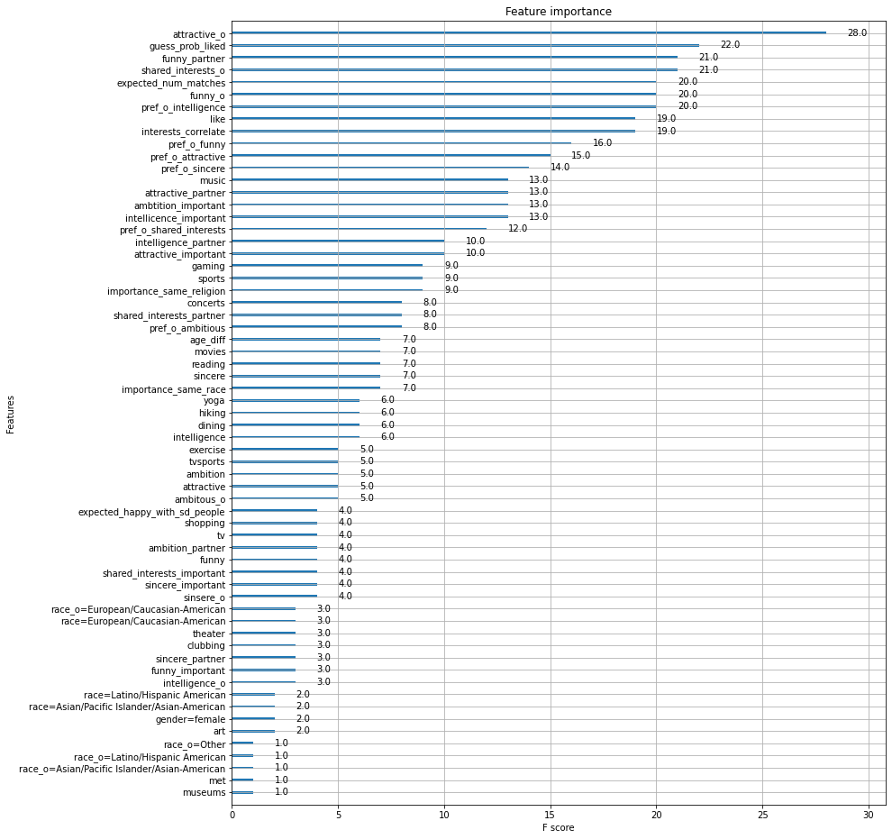

```python
# Convert the data to dmatrix
dating_matrix = xgb.DMatrix(data = X_train, label = y_train)
params = {'objective':'binary:logistic'}

# Train data using dmatrix format
xgb_clf = xgb.train(dtrain = dating_matrix, params = params, num_boost_round = 10)

# Plot the feature importances
fig, ax  = plt.subplots(figsize = (13,16))
xgb.plot_importance(xgb_clf, ax = ax)
plt.show()
```

In xgboost, the scores of each feature can be retrieved using the .get_score() method

```python
xgb_features = pd.DataFrame(xgb_clf.get_score(), index = ['score']).T
xgb_features['score'].sort_values(ascending=False).head(8)
```

```
attractive_o            28.0
guess_prob_liked        22.0
shared_interests_o      21.0
funny_partner           21.0
pref_o_intelligence     20.0
expected_num_matches    20.0
funny_o                 20.0
interests_correlate     19.0
Name: score, dtype: float64
```

We will evaluate the accuracy of the model with features with a score greater than 3. This selects 47 features which does not greatly affect our accuracy.

```python
xgb_cl = xgb.XGBClassifier()

# Selecting features
xgb_top_features = xgb_features[xgb_features['score'] > 3].index

# Fit and predict
xgb_cl.fit(X_train[xgb_top_features],y_train)
y_pred = xgb_cl.predict(X_test[xgb_top_features])
accuracy = (np.sum(y_pred == y_test))/(len(y_pred))
print(f'Dropping features from 70 to {len(xgb_top_features)} results in an accuracy of {accuracy}')
```

```
Dropping features from 70 to 47 results in an accuracy of 0.8696897374701671
```

## 8.3 Dimension reduction with Recursive Feature Elimination - RFE

RFE is feature selection algorithm that produces feature importances or feature coeffients when a model is passed to it. It fits the model and drops the weakest features, and repeats the process until the specified number of features is attained. Using xgboost classifier, we test the accuracy of different number of features As seen below, the accuracy of a model with 70 features isn't very different with a model fitted with 40 features. In fact, reducing features from 30 to 15 has an insignificant impact on the model's accuracy. In essence, if you are more concerned with what features play an important role in your prediction, the automatic selection of features by the recursive feature elimination method is very effective. In this circumstance, it's a tradeoff between dimensionality and accuracy.

```python
from sklearn.feature_selection import RFE

xgb_cl = xgb.XGBClassifier()

for features in list(range(70,1,-5)):
    # Instantiate and fit the RFE
    rfe = RFE(estimator = xgb_cl, n_features_to_select = features)
    rfe.fit(X_train,y_train)

    # Make predictions
    y_pred = rfe.predict(X_test)
    accuracy = (np.sum(y_pred == y_test))/(len(y_pred))
    print(f'The accuracy of {features} features is {accuracy}')
```

```
The accuracy of 70 features is 0.8749403341288783
The accuracy of 65 features is 0.8711217183770883
The accuracy of 60 features is 0.8692124105011934
The accuracy of 55 features is 0.8744630071599045
The accuracy of 50 features is 0.8735083532219571
The accuracy of 45 features is 0.8701670644391408
The accuracy of 40 features is 0.8706443914081146
The accuracy of 35 features is 0.8634844868735083
The accuracy of 30 features is 0.8663484486873508
The accuracy of 25 features is 0.867780429594272
The accuracy of 20 features is 0.8601431980906922
The accuracy of 15 features is 0.863961813842482
The accuracy of 10 features is 0.8658711217183771
The accuracy of 5 features is 0.847255369928401
```

### 8.3.1 Selecting the features

Suppose we want a balance between dimensionality of the dataset and the accuracy, we can select 15 features whose accuracy is 0.86. The .support_ attribute is used to give a mask with True and False values for features selected and those not selected respectively.

```python
xgb_cl = xgb.XGBClassifier()

# Instatiate RFE with 15 features
rfe = RFE(estimator = xgb.XGBClassifier(), n_features_to_select = 15)

# Fit and predict
rfe.fit(X_train,y_train)
y_pred = rfe.predict(X_test)
accuracy = (np.sum(y_pred == y_test))/(len(y_pred))
print(f'Model accuracy is {accuracy}')

# Select a mask with features selected
mask = rfe.support_
xgb_top_15_features = X_train.columns[mask].tolist()
print(f'\nTop 15 features in the xgb classifier are:\n{xgb_top_15_features}')
```

```
Model accuracy is 0.863961813842482

Top 15 features in the xgb classifier are:
['pref_o_intelligence', 'attractive_o', 'funny_o', 'shared_interests_o', 'attractive_important', 'intellicence_important', 'attractive', 'attractive_partner', 'funny_partner', 'hiking', 'movies', 'expected_num_matches', 'like', 'guess_prob_liked', 'met']
```

### 8.3.2 Combining features from different models

You can use different models and choose features with selected by all the models, and then use these features for prediction. We will select the top 30 features in three models and select common features

#### Selecting random forest features

```python
rf = RandomForestClassifier()

rfe = RFE(estimator = rf, n_features_to_select = 30)
rfe.fit(X_train,y_train)
y_pred = rfe.predict(X_test)
accuracy = (np.sum(y_pred == y_test))/(len(y_pred))
print(f'Model accuracy is {accuracy}')

mask_rfe = rfe.support_
```

```
Model accuracy is 0.8682577565632458
```

#### Selecting logistic Regression features

```python
logreg = LogisticRegression(max_iter =100000)

rfe = RFE(estimator = logreg, n_features_to_select = 30)
rfe.fit(X_train,y_train)
y_pred = rfe.predict(X_test)
accuracy = (np.sum(y_pred == y_test))/(len(y_pred))
print(f'Model accuracy is {accuracy}')

mask_log = rfe.support_
```

```
Model accuracy is 0.8625298329355608
```

#### Selecting xgboost features

```python
xgb_cl = xgb.XGBClassifier()

rfe = RFE(estimator = xgb_cl, n_features_to_select = 30)
rfe.fit(X_train,y_train)
y_pred = rfe.predict(X_test)
accuracy = (np.sum(y_pred == y_test))/(len(y_pred))
print(f'Model accuracy is {accuracy}')

mask_xgb = rfe.support_
```

```
Model accuracy is 0.8663484486873508
```

### 8.3.3 Evaluating features selected by the three classifiers

After selecting 30 features in all our models, we will combine them to select features chosen by all the models. We will use these features for our prediction. A total of 11 features were present in all the models.

```python
# Find sum of mask to identify common features
mask_all_models = np.sum([mask_rfe, mask_log,mask_xgb], axis=0)

# Select features selected by all the three models
mask = mask_all_models == 3
most_important_features = X_train.columns[mask]

print(most_important_features.shape)
print()
print(most_important_features)
```

```
(11,)

Index(['pref_o_intelligence', 'attractive_o', 'funny_o', 'shared_interests_o',
       'attractive_important', 'ambtition_important', 'attractive_partner',
       'funny_partner', 'expected_num_matches', 'like', 'guess_prob_liked'],
      dtype='object')
```

When the 11 features selected by the three models are evaluated, they give an accuracy of 0.863 with xgboost, a value not very far from 0.875 when using 70 features.

```python
xg_cl = xgb.XGBClassifier()

xg_cl.fit(X_train[most_important_features], y_train)
y_pred = xg_cl.predict(X_test[most_important_features])
accuracy = (np.sum(y_pred == y_test))/(len(y_pred))
print(f'Accuracy of 11 features selected by all models is {accuracy}')
```

```
Accuracy of 11 features selected by all models is 0.8634844868735083
```

## 8.4 Dimension reduction with PCA

PCA is another dimension-reduction technique. It has the explained_variance_ratio_ attribute that provides the variance of each feature.

```python
pca = PCA()
pca.fit(X_train, y_train)
variance = pca.explained_variance_ratio_
variance
```

```
array([9.26981372e-02, 7.33041859e-02, 5.34072404e-02, 5.23595302e-02,
       4.03272842e-02, 3.56476070e-02, 3.49903772e-02, 2.91299489e-02,
       2.59795903e-02, 2.38143307e-02, 2.34089634e-02, 2.20175478e-02,
       2.09824843e-02, 2.03839325e-02, 1.97322232e-02, 1.93722168e-02,
       1.84591183e-02, 1.79989329e-02, 1.76005903e-02, 1.69436094e-02,
       1.65425638e-02, 1.60193268e-02, 1.56413127e-02, 1.49585547e-02,
       1.47031287e-02, 1.40780449e-02, 1.39806460e-02, 1.31456652e-02,
       1.26551068e-02, 1.21945011e-02, 1.21067298e-02, 1.14404479e-02,
       1.06083411e-02, 1.02603270e-02, 9.89580666e-03, 9.68783508e-03,
       9.16074348e-03, 8.79712726e-03, 8.30033233e-03, 8.14781338e-03,
       7.62529319e-03, 7.47805870e-03, 7.24608578e-03, 6.84479722e-03,
       6.43167034e-03, 6.37360759e-03, 5.78662455e-03, 5.44258999e-03,
       5.27735444e-03, 5.03121809e-03, 4.88236089e-03, 4.78409952e-03,
       4.42349683e-03, 4.08181845e-03, 3.44392786e-03, 3.27228774e-03,
       2.30599289e-03, 1.88738415e-03, 1.52177027e-03, 1.16861939e-03,
       1.11763062e-03, 9.17013251e-04, 8.11286013e-04, 3.22892017e-04,
       3.00064330e-04, 1.70952366e-04, 1.68897978e-04, 1.82814841e-32,
       3.86931694e-34, 3.86931694e-34])
```

A plot of explained variance ratio is a good indicator of the ideal number of n_components to be used in PCA. The number of components is picked from the elbow where there is an abrupt shift in explained variance. In this case, it is 11.

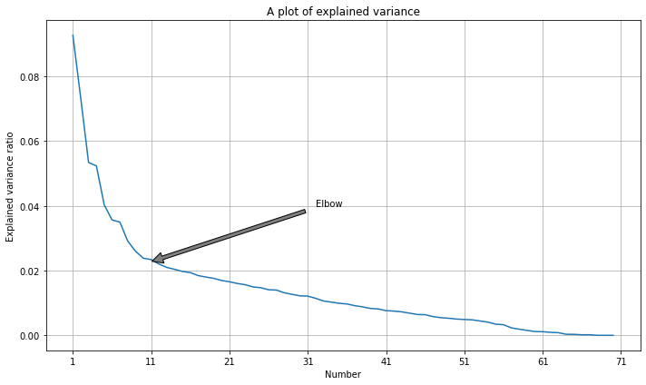

```python
fig = plt.figure(figsize = (10,6))
plt.plot(variance)
plt.grid(True)
plt.xlabel('Number')
plt.ylabel('Explained variance ratio')
plt.title('A plot of explained variance')
plt.xticks(np.arange(0,80,10), np.arange(1,81,10))
plt.annotate('Elbow',xy =[9, 0.022], xytext = [31, 0.04], arrowprops=dict(facecolor='grey', shrink=0.05))
plt.tight_layout()
plt.show()
```

Using the number of components from the elbow, we fit_transform the train dataset and tranform the test set. Using the xgb classifier after reducing the dimensions of data from 70 to 11 features results in an accuracy of 0.85, a slight drop from 0.87 when using 70 features.

```python
# Instantiate PCA with 11 components
pca = PCA(n_components = 11)

xgb_cl = xgb.XGBClassifier()

# Fit and transform the training set
X_train_transformed = pca.fit_transform(X_train)

# Transform the test set
X_test_tranformed = pca.transform(X_test)

# Fit and predict with the transformed datasets
xgb_cl.fit(X_train_transformed,y_train)
y_pred = xgb_cl.predict(X_test_tranformed)
accuracy = (np.sum(y_pred == y_test))/(len(y_pred))
print(accuracy)
```

```
0.8463007159904534
```